# SATGPA - Information Preserving Statistical Obfuscation (IPSO)

Evaluation Synthetic Data Creation

Steffen Moritz, Hariolf Merkle, Felix Geyer, Michel Reiffert, Reinhard Tent (DESTATIS)

January 28, 2022

# Executive Summary

We used **IPSO** with the `RegSDC` R package. Just looking at our main privacy and usability metrics, IPSO di not perform too well. Out of all different methods we tested (`FCS`, `IPSO`, `GAN`, `Simulation`, `Minutemen`) it seems like IPSO is clearly the worst. While in most cases the other algorithms tend to be on the pareto front in terms of **utility / privacy trade-off**, IPSO just seems to have overall bad results. But, taking a closer look, that also has to do with the fact that our main metrics are not very good at evaluating IPSO. The reader should be aware, that **only a part** of the IPSO dataset is **actually synthetic**. This fact should be weighted in an evaluation of this algorithm. For the right use case IPSO might be a good choice. The `S_pMSE` for tables and for distributions is usually below 10 for the synthetic part. The Mahalanobis distance of the regression parameters never exceeded the critical value. There **is also reasonable usability** according to Mlodak’s information loss criterion.

Based on the results of this document, we rate the suitability of this synthetic dataset for the use cases as follows:

**USE CASE RECOMMENDATIONS**

| Releasing_to_Public | Testing_Analysis | Education | Testing_Technology |
| --- | --- | --- | --- |
| NO | MAYBE | NO | NO |

Since IPSO did not score too well on our privacy metrics, we would only release the synthetic data to trusted partners. Thus, **education** and **releasing to the public** does not seem like a good option for us. We also think there are better options for **technology testing**,. We could imagine **testing analysis** could be a good fit, if the choice of **confidetial** and **non-confidential** is a good fit for the analysis planned by the researchers.

# Dataset Considerations

When deciding, if data is released to the public it is of utmost importance to define, **which variables** are the **most relevant** in terms of **privacy and utility**. This process is very **domain and country specific**, since different areas of the world have different privacy legislation and feature specific overall circumstances. This step would require input and discussions with actual domain experts. Since we are foreign to US privacy law and there is no SAT equivalent in Germany, the assumptions made for the Synthetic Data Challenge are basically a **educated guess** from our side.

From a **utility perspective** it is important to know which variables and correlations are most interesting for actual users of the created synthetic dataset. Different use cases might require focus on different variables and correlations. We could not single out a most important variable, thus in our utility analysis we decided to focus on the overall SAT utility and **not to prioritize a specific variable**. From a data plausibility perspective it was essential to us, that the `sat_v + sat_m = sat_sum` stay consistent.

# Method Considerations

Similar to the FCS-method, IPSO is **easy to understand and to explain**, since it is based on classic linear regression. For applying IPSO, we chose the R package **RegSDC** that provides a framework containing several versions of the method. We applied classical version of IPSO provided by the function RegSDCipso.

IPSO requires to split up the variables in **non-confidential** ones and **confidential** ones. It assumes statistical independence among the non-confidential variables and multivariate normally distributed confidential variables. The assumption is strong, however, for the dataset SAT it is sufficiently met. We classified the sat-related variables and sex as non-confidential and the gpa-related variables as confidential. The computation time for IPSO was among the best of our tested methods.

# Privacy and Risk Evaluation

### Disclosure Risk (R-Package: synthpop with own Improvements)

Our starting point was the **matching of unique records**, as described in the disclosure risk measures chapter of the starter guide. The synthpop package provides us with an easy-to-use implementation of this method: `replicated.uniques`. However, one downside of just using `replicated.uniques` is that it does **not consider almost exact matches in numeric variables**. Imagine a data set with information about the respondents’ income. If there is a matching data point in the synthetic data set for a unique person in the original data set, that only differs by a slight margin, the original function would not identify this as a match. **Our solution** is to borrow the notion of the **p% rule** from **cell suppression methods**, which identifies a data point as critical, if one can guess the original values with **some error of at most p%**. Thus, **our improved risk measure** is able to evaluate disclosure risk in numeric data. Our Uniqueness-Measure for **“almost exact”** matches provides us with the following outputs:

- **Replication Uniques** | Number of unique records in the synthetic data set that replicates unique records in the original data set w.r.t. their quasi-identifying variables. In brackets, the proportion of replicated uniques in the synthetical data set relative to the original data set size is stated.
- **Disclosure in >= 1 CVar** | Number of replicated unique records in the synthetical data set that have a real disclosure risk in at least one confidential variable, i.e. there is at least one confidential variable where the record in the synthetical data set is “too close” to the matching unique record in the original data set. We identify two records as “too close” in a variable, if they differ in this variable by at most p%. In brackets, the described number is given in proportion to the original data set size.
- **Disclosure in 2 CVars** | Number of replicated unique records in the synthetical data set that have a real disclosure risk in both confidential variables, i.e. in both of the confidential variables the record in the synthetical data set is “too close” to the matching unique record in the original data set. We identify two records as “too close” in a variable, if they differ in this variable by at most p%. In brackets, the described number is given in proportion to the original data set size.

For our selected best parametrized solution in this method-category, we got the following results:

| Replication.Uniques | Disclosure.in.>=1.CVar | Disclosure.in.2.CVars |
| --- | --- | --- |
| 551 (55.1%) | 159 (15.9%) | 16 (1.6%) |

## Perceived Disclosure Risk (R-Package: synthpop)

Unique records in the synthetic dataset may be **mistaken for unique records** based on the fact, that **only the identifying variables match**. This can lead to problems, even if the associated confidential variables significantly differ from the original record. E.g. people might assume a certain income for a person, because they believe to have identified him from the identifying variables. Even if his real income **is not leaked** (as the confidential variables are different), this assumed (but wrong) information about him **might lead to disadvantages**. The **perceived risk** is measured by matching the unique records among the identifying variables, in our case `sex`, `sat_v`, `sat_m`and `sat_sum`. We applied the method `replicated.uniques` of the synthpop package. There is no fixed threshold that must not be exceeded in this measure, however, a smaller percentage of unique matches (referred to as Number Replications) is preferred to minimize the perceived disclosure risk.

These are the results variables for perceived disclosure risk:

- **Number Uniques** | Number of unique individuals in the original data set.
- **Number Replications** | The number of matching records in the synthetic data set (based only on identifying variables). This is the number of individuals, which might perceived as disclosed (real disclosures would also count into this metric)
- **Percentage Replications** | The calculated percentage of duplicates in the synthetic data

For our selected best solution for the synthetic generation methods, we got the following results:

| Metric | Number.Uniques | Number.Replications | Percentage.Replications |
| --- | --- | --- | --- |
| Perceived Risk | 551 | 551 | 55.1 |

# Utility Evaluation

Different utility measures are applied in this section. These utility measures are the basis of the utility evaluation of the generated synthetic dataset. These are the utility measures for our selected dataset after optimizations and tuning.

### Graphical Comparison for Margins (R-Package: synthpop)

The following histograms provide an ad-hoc overview on the marginal distributions of the original and synthetic dataset. Matching or close distributions are related to a high data utility.

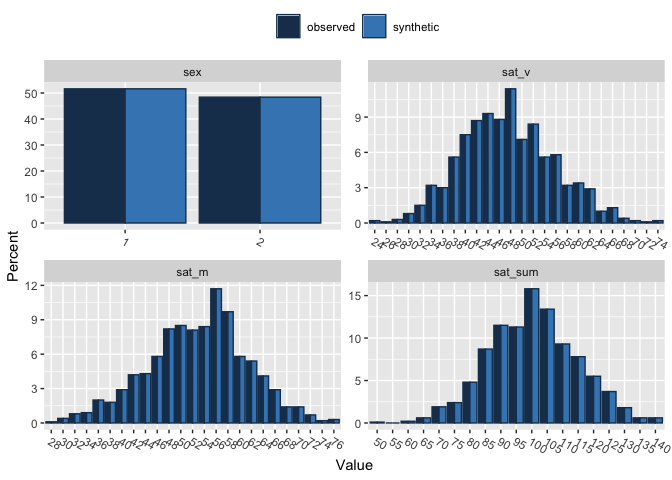

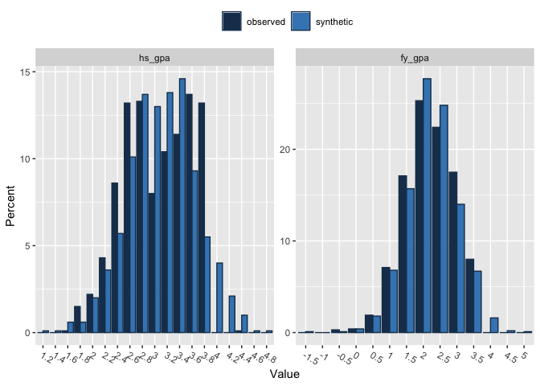

### Correlation Plots for Graphical Comparison of Pearson Correlation

Synthetic Datasets should represent the dependencies of the original datasets. The following correlation plots provide an ad-hoc overview on the Pearson correlations of the original and synthetic dataset. The left plot shows the original correlation whereas the right plot provides the correlation based on the synthetic dataset.

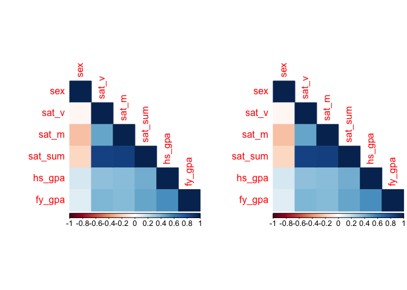

### Kolmogorov-Smirnov Test

The Kolmogorov-Smirnov test is a classic way to compare (marginal) distributions. A significant result indicates that the two distributions are not identical. The following statistic show the share of variables in the synthetic dataset that have a p-value > 5%. (1: 100%, 0: 0%)

| Mean_KS_not_signif |
| --- |
| 0.83 |

### Mahalanobis Distance for Regression Parameters

To assess testing analysis, coefficients and standard errors calculated based on synthetic dataset should lead to the same results when calculated on the original data. The evaluate differences and taking the variance covariance matrix into account, we calculated the mahalanobis distance between the respective regression parameters. Since we used several regression models, we present the mean of cases in which the mahalanobis distance exceeded the critial value (0: excellent; 1: poor).

| Mahalanobis.Distance |
| --- |
| 0 |

### Distributional Comparison of Synthesised Data (R-Package: synthpop) by (S_)pMSE

Propensity scores are calculated on a combined dataset (original and synthetic). A model (here: CART) tries to identify the synthetic units in the dataset. Since both datasets should be identically structured, the pMSE should equal zero. The S_pMSE (standardised pMSE) should not exceed 10 and for a good fit below 3 according to Raab (2021, https://unece.org/sites/default/files/2021-12/SDC2021_Day2_Raab_AD.pdf)

|  | pMSE | S_pMSE | df |
| --- | --- | --- | --- |
| sex | 0.0000000 | 0.00000 | 1 |
| sat_v | 0.0000000 | 0.00000 | 4 |
| sat_m | 0.0000000 | 0.00000 | 4 |
| sat_sum | 0.0000000 | 0.00000 | 4 |
| hs_gpa | 0.0077675 | 31.07004 | 4 |
| fy_gpa | 0.0006493 | 2.59725 | 4 |

| pMSE | S_pMSE |
| --- | --- |
| 0.2278401 | 5.735209 |

### Two-way Tables Comparison of Synthesised Data (R-Package: synthpop) by (S_)pMSE

Two-way tables are evaluated based on the original and the synthetic dataset. Here, tables/cells are also evaluated based on pMSE and S_pMSE (see above). We also present the results for the mean absolute difference in densities (MabsDD).

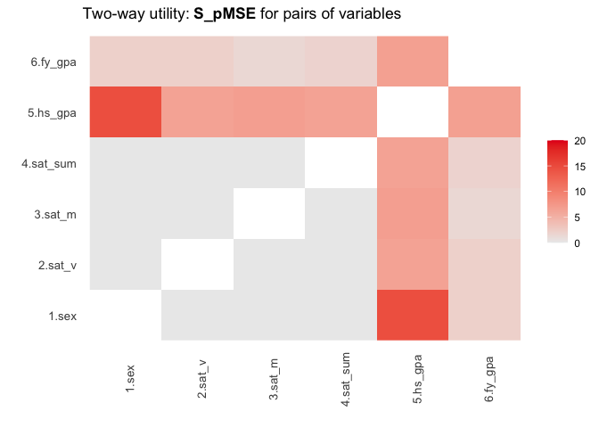

|  | pMSE | S_pMSE | MabsDD |
| --- | --- | --- | --- |
| 1.sex:2.sat_v | 0.0000000 | 0.000000 | 0.000 |
| 1.sex:3.sat_m | 0.0000000 | 0.000000 | 0.000 |
| 1.sex:4.sat_sum | 0.0000000 | 0.000000 | 0.000 |
| 1.sex:5.hs_gpa | 0.0082572 | 14.679483 | 0.324 |
| 1.sex:6.fy_gpa | 0.0011337 | 2.015414 | 0.118 |
| 2.sat_v:3.sat_m | 0.0000000 | 0.000000 | 0.000 |
| 2.sat_v:4.sat_sum | 0.0000000 | 0.000000 | 0.000 |
| 2.sat_v:5.hs_gpa | 0.0096238 | 6.415884 | 0.336 |
| 2.sat_v:6.fy_gpa | 0.0031230 | 2.082029 | 0.178 |
| 3.sat_m:4.sat_sum | 0.0000000 | 0.000000 | 0.000 |
| 3.sat_m:5.hs_gpa | 0.0102120 | 6.808027 | 0.326 |
| 3.sat_m:6.fy_gpa | 0.0021349 | 1.423280 | 0.158 |
| 4.sat_sum:5.hs_gpa | 0.0096286 | 6.419054 | 0.336 |
| 4.sat_sum:6.fy_gpa | 0.0027313 | 1.820896 | 0.164 |
| 5.hs_gpa:6.fy_gpa | 0.0100106 | 6.673733 | 0.334 |

### Information Loss Measure Proposed by Andrzej Mlodak (R-Package: sdcMicro)

The value of this information loss criterion is between 0 (no information loss) and 1. It is calculated overall and for each variable.

| Information.Loss |
| --- |
| 0.1058059 |

Individual Distances for Information Loss:

| sex | sat_v | sat_m | sat_sum | hs_gpa | fy_gpa |
| --- | --- | --- | --- | --- | --- |
| 0 | 0 | 0 | 0 | 0.2843878 | 0.3504478 |